# Regression-SEA-building-energy-bechmarking

Christopher Lacrampe

November 14, 2018

The aim of this predictive model is to be able to identify buildings on the basis of being able to obtain Energy Star Certification (Energy Star Score >= 75). By training a Regression, we can measure the factors that impact energy star score the most, which can help buildings in the Seattle area that have not enrolled in the energy star program, but have access to the same variables as our training and test sets (so that they can improve their score in the future).

# 1. Loading, cleaning, and preparing the data/libraries

### 1.1 Loading libraries and datasets

```r
library(psych)
library(tidyverse) # has useful libraries for cleaning and filtering data
energyDat2016 = read.csv("sea-building-energy-benchmarking/2015-building-energy-benchmarking.csv", stringsAsFactors = FALSE)
```

### 1.2 Cleaning the data

#### 1.2.1 Removing outliers

Our dataset has come prepared with an **Outlier** feature where the data controller has flagged outliers as “High” and “Low”, we will remove those outliers

```r
energyDat2016 = tbl_df(filter(energyDat2016, Outlier == ""))
energyDat2016 = as.data.frame(energyDat2016)
```

#### 1.2.2 Create a dataframe utilizing the variables we want to include in our model (this strips redundant variables that are identical to the others just measured in different units)

```r
modelDat = select(energyDat2016, ENERGYSTARScore, YearBuilt, PropertyGFATotal, SiteEUIWN.kBtu.sf., Electricity.kBtu., NaturalGas.kBtu., GHGEmissionsIntensity.kgCO2e.ft2.)
# remove NA values
modelDat = na.omit(modelDat)
```

# 2. Exploring the data

#### 2.1 Enhanced scatterplot matrix

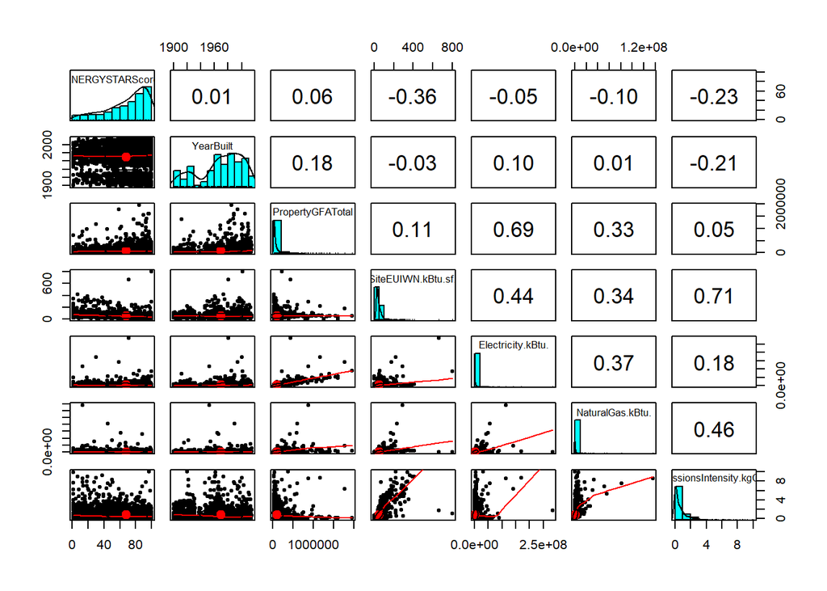

```r
pairs.panels(modelDat)
```

In the upper right triangle of the matrix we see the correlations between each of the numerical features. Along the main diagonal we see a histogram of each feature’s distribution. In the lower triangular portion we see scatterplots between two features. The red line is a loess curve that somewhat models the relationship between the two variables. The ellipse represents the strength of the correlation with the center dot indicating the mean point (many of the ellipses are centered, so the correlation between features isn’t very strong).

# 3. Training a model on the data

### 3.1 Use the lm() method to fit a linear model to the data. Name it energy_model

```r
energy_model = lm(ENERGYSTARScore ~ YearBuilt + PropertyGFATotal + SiteEUIWN.kBtu.sf. + Electricity.kBtu. + NaturalGas.kBtu. + GHGEmissionsIntensity.kgCO2e.ft2., data = modelDat)
```

### 3.2 Show the estimated Beta coefficients. Explain the results

```r
summary(energy_model)
```

```
##
## Call:
## lm(formula = ENERGYSTARScore ~ YearBuilt + PropertyGFATotal +
##     SiteEUIWN.kBtu.sf. + Electricity.kBtu. + NaturalGas.kBtu. +
##     GHGEmissionsIntensity.kgCO2e.ft2., data = modelDat)
##
## Residuals:
##     Min      1Q  Median      3Q     Max
## -81.477 -14.373   6.529  18.988 215.783
##
## Coefficients:
##                                     Estimate Std. Error t value Pr(>|t|)
## (Intercept)                        8.078e+01  3.231e+01   2.500 0.012477
## YearBuilt                         -5.197e-04  1.644e-02  -0.032 0.974792
## PropertyGFATotal                   4.047e-06  4.915e-06   0.824 0.410269
## SiteEUIWN.kBtu.sf.                -2.885e-01  1.890e-02 -15.260  < 2e-16
## Electricity.kBtu.                  3.777e-07  8.461e-08   4.464 8.41e-06
## NaturalGas.kBtu.                  -2.796e-07  1.448e-07  -1.931 0.053638
## GHGEmissionsIntensity.kgCO2e.ft2.  2.325e+00  6.855e-01   3.392 0.000704
##
## (Intercept)                       *
## YearBuilt
## PropertyGFATotal
## SiteEUIWN.kBtu.sf.                ***
## Electricity.kBtu.                 ***
## NaturalGas.kBtu.                  .
## GHGEmissionsIntensity.kgCO2e.ft2. ***
## ---
## Signif. codes:  0 '***' 0.001 '**' 0.01 '*' 0.05 '.' 0.1 ' ' 1
##
## Residual standard error: 24.51 on 2484 degrees of freedom
## Multiple R-squared:  0.1491, Adjusted R-squared:  0.1471
## F-statistic: 72.55 on 6 and 2484 DF,  p-value: < 2.2e-16
```

From this summary output we can see that for each increase in YearBuilt we see a decrease in ENERGYSTARScore of -5.197e-04. As the PropertyGFATotal increases by one square foot, we can expect an increase in ENERGYSTARScore of 4.047e-06. As Electricity.kBtu. increases by one kBtu the ENERGYSTARScore increases 3.777e-07. As NaturalGas.kBtu. increases by one kBtu, ENERGYSTARScore decreases by -2.796e-07. As GHGEmissionsIntensity.kgCO2e.ft2. increases by one unit, ENERGYSTARScore increases by 2.325e points. The Adjusted R-squared of 0.1471 indicates that 14.71% of the variation in ENERGYSTARScore is explained by the model.

# 4. Improving model performance

### 4.1 Adding nonlinear relationships

```r
modelDat$YearBuilt2 = modelDat$YearBuilt^2
```

We can square the year built (and think of it as a relationship) where newer building are more likely to be energy efficient and older building are more likely to be renovated (with the middle section being the least efficient)

### 4.2 Transformation - converting a numerical variable to a binary indicator

```r
modelDat$PropertyGFATotalMedian = ifelse(modelDat$PropertyGFATotal >= median(modelDat$PropertyGFATotal), 1, 0)
```

Although this might not be useful, we can split the PropertyGFATotal along the median into two bins and make a dummy variable that may work better.

### 4.3 Model specification - adding interaction effects

```r
ENERGYSTARScore ~ NaturalGas.kBtu.*PropertyGFATotalMedian
```

```
## ENERGYSTARScore ~ NaturalGas.kBtu. * PropertyGFATotalMedian
```

### 4.4 Creating a model with these features

```r
energy_model2 = lm(ENERGYSTARScore ~ YearBuilt + YearBuilt2 + PropertyGFATotal + SiteEUIWN.kBtu.sf. + Electricity.kBtu. + NaturalGas.kBtu.*PropertyGFATotalMedian + GHGEmissionsIntensity.kgCO2e.ft2., data = modelDat)
```

#### 4.4.1 Evaluate model performance with the summary() function

```r
summary(energy_model2)
```

```
##
## Call:
## lm(formula = ENERGYSTARScore ~ YearBuilt + YearBuilt2 + PropertyGFATotal +
##     SiteEUIWN.kBtu.sf. + Electricity.kBtu. + NaturalGas.kBtu. *
##     PropertyGFATotalMedian + GHGEmissionsIntensity.kgCO2e.ft2.,
##     data = modelDat)
##
## Residuals:
##    Min     1Q Median     3Q    Max
## -77.26 -14.44   6.55  18.26 214.73
##
## Coefficients:
##                                           Estimate Std. Error t value
## (Intercept)                              1.299e+04  1.966e+03   6.605
## YearBuilt                               -1.318e+01  2.008e+00  -6.562
## YearBuilt2                               3.361e-03  5.125e-04   6.558
## PropertyGFATotal                        -4.728e-06  5.233e-06  -0.903
## SiteEUIWN.kBtu.sf.                      -2.980e-01  1.893e-02 -15.742
## Electricity.kBtu.                        4.599e-07  8.539e-08   5.386
## NaturalGas.kBtu.                         2.878e-06  1.433e-06   2.009
## PropertyGFATotalMedian                   3.110e+00  1.249e+00   2.490
## GHGEmissionsIntensity.kgCO2e.ft2.        1.455e+00  8.076e-01   1.802
## NaturalGas.kBtu.:PropertyGFATotalMedian -3.068e-06  1.385e-06  -2.215
##                                         Pr(>|t|)
## (Intercept)                             4.84e-11 ***
## YearBuilt                               6.45e-11 ***
## YearBuilt2                              6.61e-11 ***
## PropertyGFATotal                          0.3664
## SiteEUIWN.kBtu.sf.                       < 2e-16 ***
## Electricity.kBtu.                       7.89e-08 ***
## NaturalGas.kBtu.                          0.0446 *
## PropertyGFATotalMedian                    0.0129 *
## GHGEmissionsIntensity.kgCO2e.ft2.         0.0717 .
## NaturalGas.kBtu.:PropertyGFATotalMedian   0.0269 *
## ---
## Signif. codes:  0 '***' 0.001 '**' 0.01 '*' 0.05 '.' 0.1 ' ' 1
##
## Residual standard error: 24.25 on 2481 degrees of freedom
## Multiple R-squared:  0.1681, Adjusted R-squared:  0.1651
## F-statistic:  55.7 on 9 and 2481 DF,  p-value: < 2.2e-16
```

From this output, we see our adjusted R-squared increase to 0.1651 such that 16.51% of the variation in ENERGYSTARScore is explained by the model. While YearBuilt has become statistically significant at the 1% level, we see sign reversals for some key variables like NaturalGas.kBtu. This seems conterintuitive–an increase in natural gas usage increases the energy star score would be counter productive (we would expect this to be negative). From the low correlations in the exploratory sections and the low R-Squared values and switching signs for the coefficients from our output models, Regression appears to be a poor model for this information.